# day-11/12

Author

Maya McCain

#Part 1: Normality Testing

#Load the airquality dataset in R. What does this dataset represent? Explore its structure using functions like str() and summary().

```r
library(tidyverse)
library(dplyr)
library(visdat)
library(skimr)
data(airquality)
str(airquality)
```

```
'data.frame':   153 obs. of  6 variables:
 $ Ozone  : int  41 36 12 18 NA 28 23 19 8 NA ...
 $ Solar.R: int  190 118 149 313 NA NA 299 99 19 194 ...
 $ Wind   : num  7.4 8 12.6 11.5 14.3 14.9 8.6 13.8 20.1 8.6 ...
 $ Temp   : int  67 72 74 62 56 66 65 59 61 69 ...
 $ Month  : int  5 5 5 5 5 5 5 5 5 5 ...
 $ Day    : int  1 2 3 4 5 6 7 8 9 10 ...
```

```r
summary(airquality)
```

```
     Ozone           Solar.R           Wind             Temp
 Min.   :  1.00   Min.   :  7.0   Min.   : 1.700   Min.   :56.00
 1st Qu.: 18.00   1st Qu.:115.8   1st Qu.: 7.400   1st Qu.:72.00
 Median : 31.50   Median :205.0   Median : 9.700   Median :79.00
 Mean   : 42.13   Mean   :185.9   Mean   : 9.958   Mean   :77.88
 3rd Qu.: 63.25   3rd Qu.:258.8   3rd Qu.:11.500   3rd Qu.:85.00
 Max.   :168.00   Max.   :334.0   Max.   :20.700   Max.   :97.00
 NA's   :37       NA's   :7
     Month            Day
 Min.   :5.000   Min.   : 1.0
 1st Qu.:6.000   1st Qu.: 8.0
 Median :7.000   Median :16.0
 Mean   :6.993   Mean   :15.8
 3rd Qu.:8.000   3rd Qu.:23.0
 Max.   :9.000   Max.   :31.0
```

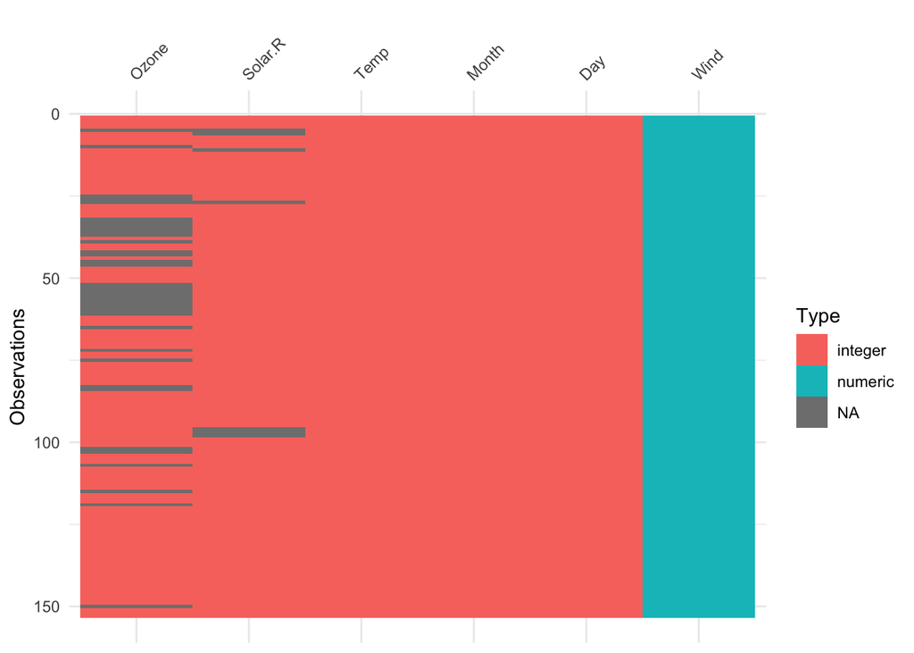

```r
?airquality
vis_dat(airquality)
```

```r
skimr::skim(airquality)
```

Data summary

| Name | airquality |
| --- | --- |
| Number of rows | 153 |
| Number of columns | 6 |
| _______________________ |  |
| Column type frequency: |  |
| numeric | 6 |
| ________________________ |  |
| Group variables | None |

**Variable type: numeric**

| skim_variable | n_missing | complete_rate | mean | sd | p0 | p25 | p50 | p75 | p100 | hist |
| --- | --- | --- | --- | --- | --- | --- | --- | --- | --- | --- |
| Ozone | 37 | 0.76 | 42.13 | 32.99 | 1.0 | 18.00 | 31.5 | 63.25 | 168.0 | ▇▃▂▁▁ |
| Solar.R | 7 | 0.95 | 185.93 | 90.06 | 7.0 | 115.75 | 205.0 | 258.75 | 334.0 | ▅▃▅▇▅ |
| Wind | 0 | 1.00 | 9.96 | 3.52 | 1.7 | 7.40 | 9.7 | 11.50 | 20.7 | ▂▇▇▃▁ |
| Temp | 0 | 1.00 | 77.88 | 9.47 | 56.0 | 72.00 | 79.0 | 85.00 | 97.0 | ▂▃▇▇▃ |
| Month | 0 | 1.00 | 6.99 | 1.42 | 5.0 | 6.00 | 7.0 | 8.00 | 9.0 | ▇▇▇▇▇ |
| Day | 0 | 1.00 | 15.80 | 8.86 | 1.0 | 8.00 | 16.0 | 23.00 | 31.0 | ▇▇▇▇▆ |

#The airquality dataset represents New York daily air quality measurements from May to September of 1973. This dataset is a data frame with 153 observations of 6 variables. There are some missing values from ozone and solar.

```r
air <- airquality
shapiro.test(air$Ozone)
```

```
    Shapiro-Wilk normality test

data:  air$Ozone
W = 0.87867, p-value = 2.79e-08
```

```r
shapiro.test(air$Temp)
```

```
    Shapiro-Wilk normality test

data:  air$Temp
W = 0.97617, p-value = 0.009319
```

```r
shapiro.test(air$Solar.R)
```

```
    Shapiro-Wilk normality test

data:  air$Solar.R
W = 0.94183, p-value = 9.492e-06
```

#What is the purpose of the Shapiro-Wilk test? #The purpose of the Shapiro-Wilk test is to test normaility of a dataset. It is very sensitive to data that is not normal, so it is good for small datasets.

#What are the null and alternative hypotheses for this test? #The null hypothesis for this test is that the data is normally distributed. The alternative hypothesis is the data is not normally distributed.

#Interpret the p-values. Are these variables normally distributed? #For ozone, temp, and solar, the p-value is < 0.05, suggesting that we reject the null hypothesis. This means that each of these variables are not normally distributed.

#Part 2: Data Transformation and Feature Engineering

#Create a new column with case_when tranlating the Months into four seasons (Winter (Nov, Dec, Jan), Spring (Feb, Mar, Apr), Summer (May, Jun, Jul), and Fall (Aug, Sep, Oct)).

```r
air <- air %>%
  mutate(Season = case_when(
    Month %in% c(11, 12, 1) ~ "Winter",
    Month %in% c(2, 3, 4) ~ "Spring",
    Month %in% c(5, 6, 7) ~ "Summer",
    Month %in% c(8, 9, 10) ~ "Fall"
  ))
```

#Use table to figure out how many observations we have from each season.

```r
table(air$Season)
```

```
  Fall Summer
    61     92
```

#There are 61 observations from Fall and 92 from Summer.

#Part 3: Data Preprocessing #Normalize the predictor variables (Temp, Solar.R, Wind, and Season) using a recipe

```r
library(recipes)
(recipe_obj <- recipe(Ozone~
                       Temp + Solar.R +
                       Wind + Season,
                      data = air) |>
  step_impute_mean(all_numeric_predictors()) |>
  step_dummy(all_factor_predictors()) |>
  step_normalize(all_numeric_predictors()))
```

```
── Recipe ──────────────────────────────────────────────────────────────────────
```

```
── Inputs
```

```
Number of variables by role
```

```
outcome:   1
predictor: 4
```

```
── Operations
```

```
• Mean imputation for: all_numeric_predictors()
```

```
• Dummy variables from: all_factor_predictors()
```

```
• Centering and scaling for: all_numeric_predictors()
```

#What is the purpose of normalizing data? #Normalizing data improves model convergence, prevents feature domination, and enhances interpretability.

#What function can be used to impute missing values with the mean? #step_impute_mean() can be used to handle missing values.

#prep and bake the data to generate a processed dataset.

```r
prep_recipe <- prep(recipe_obj, training = air)
normalized_air <- bake(prep_recipe, new_data = air) |>
  drop_na()
```

#Why is it necessary to both prep() and bake() the recipe? #prep() and bake() are both necessary because prep() estimates the parameters for the transforations (essentially calculating the steps) while bake() applies these transformations to the dataset.

#Part 4: Building a Linear Regression Model

#Fit a linear model using Ozone as the response variable and all other variables as predictors. Remeber that the . notation can we used to include all variables.

```r
library(broom)

(model = lm(Ozone ~ ., data = normalized_air))
```

```
Call:
lm(formula = Ozone ~ ., data = normalized_air)

Coefficients:
  (Intercept)           Temp        Solar.R           Wind  Season_Summer
       42.213         16.376          4.857        -10.952          1.959
```

```r
glance(model)
```

```
# A tibble: 1 × 12
  r.squared adj.r.squared sigma statistic  p.value    df logLik   AIC   BIC
      <dbl>         <dbl> <dbl>     <dbl>    <dbl> <dbl>  <dbl> <dbl> <dbl>
1     0.596         0.582  21.3      41.0 4.58e-21     4  -517. 1046. 1063.
# ℹ 3 more variables: deviance <dbl>, df.residual <int>, nobs <int>
```

#Interpret the model summary output (coefficients, R-squared, p-values) in plain language #The coefficients show how each factor affect ozone levels. Temp, solar, and summer increase ozone levels while wind decreases ozone levels. The R-squared value means that 59.6% of the variation in ozone is explained by the predicting variables. The p-value is extremely small (p-val = 4.576782e-21), therefore the relationship between ozone levels and the predicting variables are statistically significant.

#Part 5: Model Diagnostics

#Use broom::augment to suppliment the normalized data.frame with the fitted values and residuals.

```r
(pred <- augment(model, normalized_air))
```

```
# A tibble: 116 × 11
     Temp   Solar.R    Wind Ozone Season_Summer .fitted   .resid   .hat .sigma
    <dbl>     <dbl>   <dbl> <int>         <dbl>   <dbl>    <dbl>  <dbl>  <dbl>
 1 -1.15   0.0462   -0.726     41         0.812   33.2    7.85   0.0443   21.4
 2 -0.621 -0.772    -0.556     36         0.812   36.0    0.0397 0.0316   21.4
 3 -0.410 -0.420     0.750     12         0.812   26.8  -14.8    0.0227   21.4
 4 -1.68   1.44      0.438     18         0.812   18.5   -0.547  0.0704   21.4
 5 -1.26   0.000743  1.40      28         0.812    7.89  20.1    0.0334   21.3
 6 -1.36   1.29     -0.385     23         0.812   32.0   -8.98   0.0657   21.4
 7 -1.99  -0.988     1.09      19         0.812   -5.61  24.6    0.0476   21.3
 8 -1.78  -1.90      2.88       8         0.812  -26.2   34.2    0.107    21.1
 9 -0.410  0.000743 -0.868      7         0.812   46.6  -39.6    0.0296   21.1
10 -0.938  0.797    -0.0731    16         0.812   33.1  -17.1    0.0329   21.4
# ℹ 106 more rows
# ℹ 2 more variables: .cooksd <dbl>, .std.resid <dbl>
```

#Extract the residuals and visualize their distribution as a histogram and qqplot.

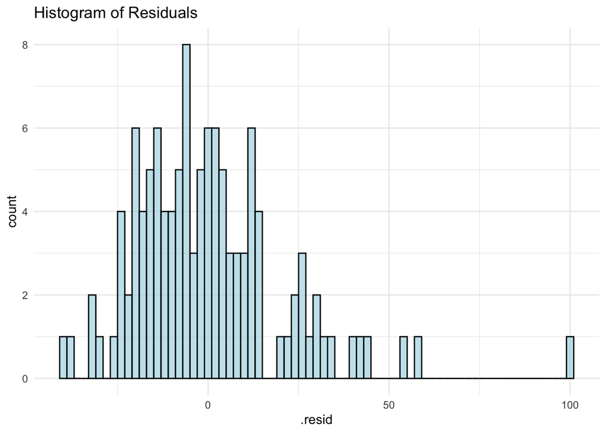

```r
residuals <- pred$.resid
hist_plot <- ggplot(pred, aes(x = .resid)) +
  geom_histogram(binwidth = 2, color = "black", fill = "lightblue", alpha = 0.7) +
  ggtitle("Histogram of Residuals") +
  theme_minimal()
print(hist_plot)
```

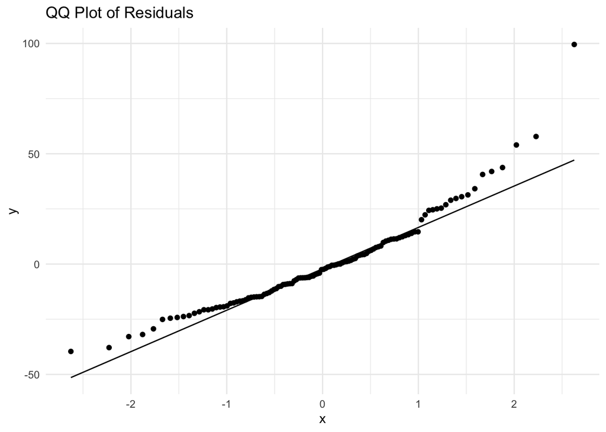

```r
qq_plot <- ggplot(pred, aes(sample = .resid)) +
  geom_qq() +
  geom_qq_line() +
  ggtitle("QQ Plot of Residuals") +
  theme_minimal()
print(qq_plot)
```

#Use ggarange to plot this as one image and interpret what you see in them.

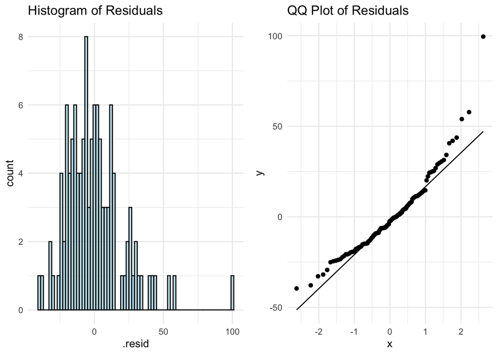

```r
library(ggplot2)
library(ggpubr)
ggarrange(hist_plot, qq_plot, ncol = 2, nrow = 1)
```

#Create a scatter plot of actual vs. predicted values using ggpubr with the following setting:

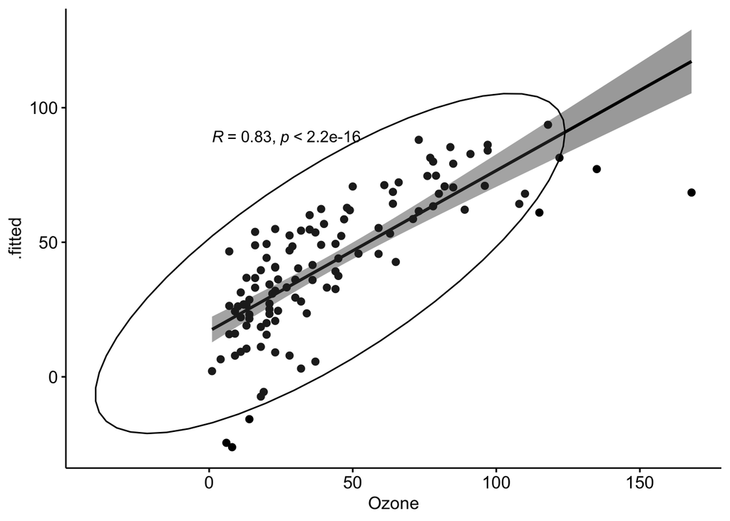

```r
ggscatter(pred, x = "Ozone", y = ".fitted",
          add = "reg.line", conf.int = TRUE,
          cor.coef = TRUE, cor.method = "spearman",
          ellipse = TRUE)
```

#How strong of a model do you think this is? #I think this is a relatively strong model because the R corelation is 0.83. There are a few outliers but overall it is a good model.